# Regresión lineal múltiple

Luis Fernando Apáez Álvarez

07 de Septiembre de 2022

## Problema tipo anova

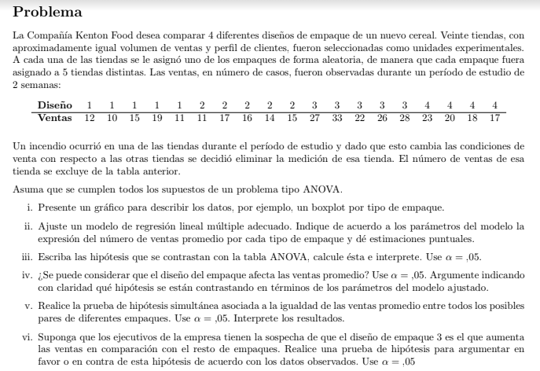

### Problema i)

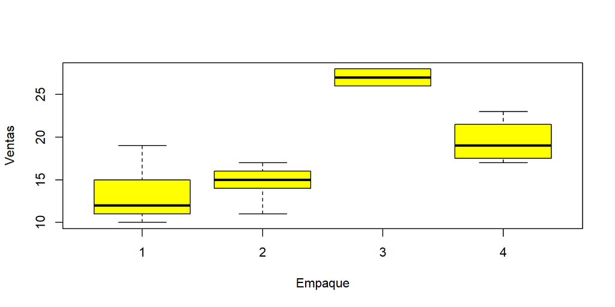

```r
Datos3 <- data.frame("Ventas"=c(12,10,15,19,11,11,17,16,14,15,27,
                                 33,22,26,28,23,20,18,17),
                    "Empaque"=as.factor(c("1","1","1","1","1",
                                          "2","2","2","2","2",
                                          "3","3","3","3","3",
                                          "4","4","4","4")))

boxplot(Ventas ~ Empaque, data=Datos3, col="yellow", outline=FALSE)
```

De esta gráfica podemos ver que en promedio las ventas del empaque 3 son mayores con respecto a las otras 3 (Empaque 1, Empaque 2, Empaque 4)

### Problema ii)

```r
levels(Datos3$Empaque)
```

```
## [1] "1" "2" "3" "4"
```

Cambiemos la variable de referencia de la variable tipo factor(empaque) Hagamos el cambio tal que nuestra referencia sea el empaque 4

```r
Datos3$Empaque <- factor(Datos3$Empaque,
                        levels=levels(Datos3$Empaque)[c(4,1,2,3)])
levels(Datos3$Empaque)
```

```
## [1] "4" "1" "2" "3"
```

Como la variable empaque tiene 4 niveles, a nuestro modelo solo van a entrar 3, la que hace referencia al empaque 1, empaque 2 y empaque 3:

$$E(Y;X) = \beta_0 + \beta_1x_1 + \beta_2x_2 + \beta_3x_3$$
Donde Y = ventas, X = empaque

$$\begin{align*}
&E(Y;X1)=\beta_0 + \beta_1\\
&E(Y;X2)=\beta_0 + \beta_2\\
&E(Y;X3)=\beta_0 + \beta_3\\
&E(Y;X4)=\beta_0
\end{align*}$$

Vamos a ajustar el modelo

```r
# b0 = 19.500
# b1 = -6.100
# b2 = -4.900
# b3 = 7.700
fit <- lm(Ventas ~ Empaque, data = Datos3)
summary(fit)
```

```
##
## Call:
## lm(formula = Ventas ~ Empaque, data = Datos3)
##
## Residuals:
##    Min     1Q Median     3Q    Max
##  -5.20  -1.95  -0.20   1.50   5.80
##
## Coefficients:
##             Estimate Std. Error t value Pr(>|t|)
## (Intercept)    19.50       1.62   12.01  4.3e-09 ***
## Empaque1       -6.10       2.18   -2.80    0.013 *
## Empaque2       -4.90       2.18   -2.25    0.040 *
## Empaque3        7.70       2.18    3.53    0.003 **
## ---
## Signif. codes:  0 '***' 0.001 '**' 0.01 '*' 0.05 '.' 0.1 ' ' 1
##
## Residual standard error: 3.2 on 15 degrees of freedom
## Multiple R-squared:  0.788,  Adjusted R-squared:  0.746
## F-statistic: 18.6 on 3 and 15 DF,  p-value: 2.58e-05
```

lo anterior nos queda estimado como

$$\begin{align*}
&E(Y;X1)=\beta_0 + \beta_1=19.500 - 6.100 = 13.4\\
&E(Y;X2)=\beta_0 + \beta_2=19.500 - 4.900 = 14.6\\
&E(Y;X3)=\beta_0 + \beta_3= 19.500 + 7.700 = 27.2\\
&E(Y;X4)=\beta_0 = 19.500
\end{align*}$$

### Problema iii)

En nuestro problema las hipotesis que se contrastan son

$$H_0: \beta_1=0 \ \ y\ \ \beta_2=0 \ \ y\ \ \beta_3=0 \ \ vs \ \ H_a:
\beta_1\neq0\ \ o\ \ \beta_2\neq0 \ \ o\ \ \beta_3\neq0$$

```r
summary(fit)
```

```
##
## Call:
## lm(formula = Ventas ~ Empaque, data = Datos3)
##
## Residuals:
##    Min     1Q Median     3Q    Max
##  -5.20  -1.95  -0.20   1.50   5.80
##
## Coefficients:
##             Estimate Std. Error t value Pr(>|t|)
## (Intercept)    19.50       1.62   12.01  4.3e-09 ***
## Empaque1       -6.10       2.18   -2.80    0.013 *
## Empaque2       -4.90       2.18   -2.25    0.040 *
## Empaque3        7.70       2.18    3.53    0.003 **
## ---
## Signif. codes:  0 '***' 0.001 '**' 0.01 '*' 0.05 '.' 0.1 ' ' 1
##
## Residual standard error: 3.2 on 15 degrees of freedom
## Multiple R-squared:  0.788,  Adjusted R-squared:  0.746
## F-statistic: 18.6 on 3 and 15 DF,  p-value: 2.58e-05
```

Con un $p-value$ de 2.585e-05 se rechaza nuestra hipotesis $H_o$. Lo que esto quiere decir es que al menos un empaque tiene un promedio distinto respecto a las ventas contra el nivel de referencia, en este caso contra el diseño 4.

### Problema iV)

Para contestar esta pregunta vamos a contrastar las siguientes hipótesis

$$H_0: \beta_1=0\ \ y\ \ \beta_2=0\ \ y\ \ \beta_3=0\ \ vs\ \ H_a:
\beta_1\neq0 \ \ o\ \ \beta_2\neq0 \ \ o\ \ \beta_3\neq0$$

```r
# Haciendo una prueba lineal general

library(multcomp)
K <- matrix(c(0,1,0,0,
              0,0,1,0,
              0,0,0,1), ncol=4, nrow=3, byrow=TRUE)
m <- c(0,0,0)
summary(glht(fit, linfct=K, rhs=m), test=Ftest())
```

```
##
##   General Linear Hypotheses
##
## Linear Hypotheses:
##        Estimate
## 1 == 0     -6.1
## 2 == 0     -4.9
## 3 == 0      7.7
##
## Global Test:
##      F DF1 DF2   Pr(>F)
## 1 18.6   3  15 2.58e-05
```

### Problema V)

Pruebas de hipótesis simultáneas (haciéndolas de par en par) usando tukey:

```r
## Usando Tukey obtenemos lo siguiente
summary(glht(fit, linfct = mcp(Empaque = "Tukey")))
```

```
##
##   Simultaneous Tests for General Linear Hypotheses
##
## Multiple Comparisons of Means: Tukey Contrasts
##
##
## Fit: lm(formula = Ventas ~ Empaque, data = Datos3)
##
## Linear Hypotheses:
##            Estimate Std. Error t value Pr(>|t|)
## 1 - 4 == 0    -6.10       2.18   -2.80    0.058 .
## 2 - 4 == 0    -4.90       2.18   -2.25    0.155
## 3 - 4 == 0     7.70       2.18    3.53    0.014 *
## 2 - 1 == 0     1.20       2.05    0.58    0.935
## 3 - 1 == 0    13.80       2.05    6.72   <0.001 ***
## 3 - 2 == 0    12.60       2.05    6.13   <0.001 ***
## ---
## Signif. codes:  0 '***' 0.001 '**' 0.01 '*' 0.05 '.' 0.1 ' ' 1
## (Adjusted p values reported -- single-step method)
```

Tomando $\alpha=0.5$, para cada par tenemos lo siguiente:

- 1 - 4 == 0: p-value = 0.0583 no se puede considerar una diferencia de forma simultanea.
- 2 - 4 == 0: p-value = 0.1547 no se puede considerar una diferencia de forma simultanea.
- 3 - 4 == 0: p-value = 0.0143 se puede considerar una diferencia de forma simultanea.
- 2 - 1 == 0: p-value = 0.9353no se puede considerar una diferencia de forma simultanea.
- 3 - 1 == 0: p-value = 0.001 se puede considerar una diferencia de forma simultanea.
- 3 - 2 == 0: p-value = 0.001 se puede considerar una diferencia de forma simultanea.

De aquí notemos que para cualquier prueba simultánea que involucre a 3, siempre nos dice que “se puede considerar una diferencia de forma simultanea”. Lo cual tiene sentido ya que nuestro empaque 3 es el que se veía que tenía en promedio una esperanza distinta con respecto a los otros empaques

### Problema Vi)

$H_0$:

$$\begin{align*}
&E(Y;X3)=\beta_0 + \beta_3 \leq E(Y;X1)= \beta_0 + \beta_1 \ \ o\\
&E(Y;X3)=\beta_0 + \beta_3 \leq E(Y;X2)= \beta_0 + \beta_2 \ \ o\\
&E(Y;X3)=\beta_0 + \beta_3 \leq E(Y;X4)= \beta_0
\end{align*}$$

versus

$H_a$:

$$\begin{align*}
&E(Y;X3)=\beta_0 + \beta_3 > E(Y;X1)= \beta_0 + \beta_1 \ \ y\\
&E(Y;X3)=\beta_0 + \beta_3 > E(Y;X2)= \beta_0 + \beta_2 \ \ y\\
&E(Y;X3)=\beta_0 + \beta_3 > E(Y;X4)= \beta_0
\end{align*}$$

```r
# Haciendo la prueba
K1 <- matrix(c(0,-1,0,1,
               0,0,-1,1,
               0,0,0,1), ncol=4, nrow=3, byrow=TRUE)
m1 <- c(0,0,0)
summary(glht(fit, linfct=K1, rhs=m1, alternative="greater"))
```

```
##
##   Simultaneous Tests for General Linear Hypotheses
##
## Fit: lm(formula = Ventas ~ Empaque, data = Datos3)
##
## Linear Hypotheses:
##        Estimate Std. Error t value Pr(>t)
## 1 <= 0    13.80       2.05    6.72 <0.001 ***
## 2 <= 0    12.60       2.05    6.13 <0.001 ***
## 3 <= 0     7.70       2.18    3.53  0.004 **
## ---
## Signif. codes:  0 '***' 0.001 '**' 0.01 '*' 0.05 '.' 0.1 ' ' 1
## (Adjusted p values reported -- single-step method)
```

Notemos que con p-values igual a 0.001 , 0.001, 0.00387 se rechaza la hipótesis nula, en términos de nuestro problema la interpretación es que podemos decir es que el diseño del empaque 3 es el que aumenta las ventas en comparación con el resto de empaques.